# **HASHING**

Hashing adalah teknik yang digunakan dalam struktur data yang secara efisien menyimpan dan mengambil data dengan cara yang memungkinkan akses cepat.

- Hashing melibatkan pemetaan data ke indeks tertentu dalam tabel hash (array item) menggunakan fungsi hash . Ini memungkinkan pengambilan informasi yang cepat berdasarkan kuncinya.
- Keunggulan hashing adalah kita dapat melakukan ketiga operasi (pencarian, penyisipan, dan penghapusan) dalam waktu O(1) rata-rata.
- Hashing terutama digunakan untuk mengimplementasikan sekumpulan item yang berbeda (hanya kunci) dan kamus (pasangan kunci-nilai).

Berikut contoh hashing menggunakan metode modulo. Fungsi hash H(x) = x % 10mengubah bilangan besar apa pun menjadi nilai yang lebih kecil antara 0 dan 9.

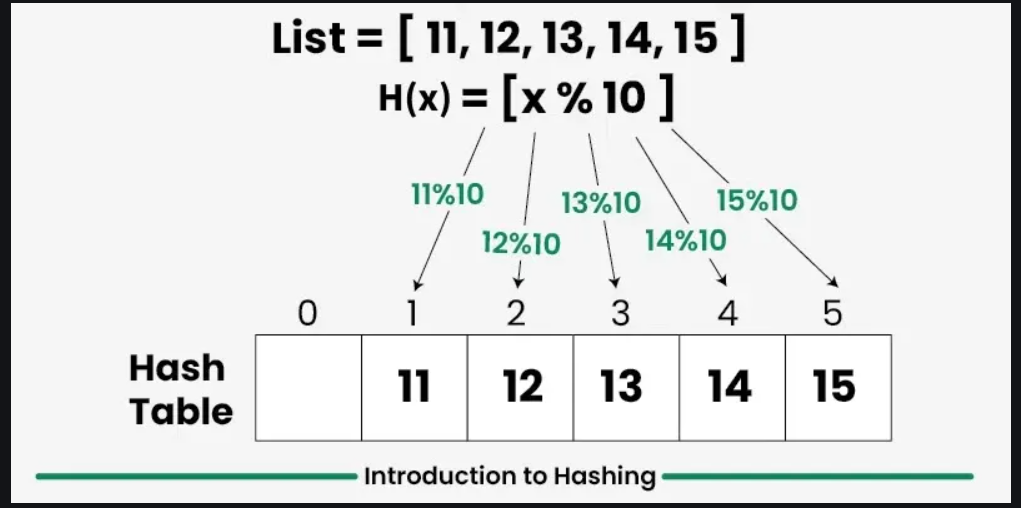

### **Gambaran Umum Struktur Data Tabel Hash**

- Ini adalah salah satu struktur data yang paling banyak digunakan setelah array.
- Pada dasarnya, ia mendukung pencarian, penyisipan, dan penghapusan dalam waktu O(1) rata-rata, yang lebih efisien daripada struktur data populer lainnya seperti array, Linked List, dan Self Balancing BST .
- Kami menggunakan hashing untuk kamus, penghitungan frekuensi, memelihara data untuk akses cepat berdasarkan kunci, dll.
- Aplikasi di dunia nyata meliputi pengindeksan basis data, kriptografi, cache, tabel simbol, dan kamus.
- Pada dasarnya ada dua bentuk hash yang umum diimplementasikan dalam bahasa pemrograman. Hash Set : Kumpulan kunci unik (Diimplementasikan sebagai Set di Python , Set di JavaScript , unordered_set di C++ dan HashSet di Java ). Hash Map : Kumpulan pasangan kunci-nilai dengan kunci yang unik (Diimplementasikan sebagai dictionary di Python, Map di JavaScript , unordered_map di C++ dan HashMap di Java ).

**Situasi di mana Hash tidak digunakan**

- Kita perlu mempertahankan data yang sudah diurutkan bersamaan dengan operasi pencarian, penyisipan, dan penghapusan. Dalam hal ini, kita menggunakan BST (Binary Search Tree) yang seimbang secara otomatis.
- Ketika string digunakan sebagai kunci dan kita membutuhkan operasi seperti pencarian awalan (prefix search) bersamaan dengan pencarian, penyisipan (insert), dan penghapusan (delete), kita menggunakan trie dalam kasus-kasus ini.
- Ketika kita membutuhkan operasi seperti pembulatan ke bawah dan ke atas, serta pencarian, penyisipan, dan/atau penghapusan, kita menggunakan BST Penyeimbang Mandiri (Self Balancing BST) dalam kasus-kasus ini.

**Komponen Hashing**

Secara garis besar, hashing terdiri dari tiga komponen:

1. **Kunci:** Kunci dapat berupa string atau bilangan bulat apa pun yang dimasukkan sebagai input ke dalam fungsi hash, yaitu teknik yang menentukan indeks atau lokasi penyimpanan suatu item dalam struktur data.
2. **Fungsi Hash:** Menerima kunci masukan dan mengembalikan indeks elemen dalam sebuah array yang disebut tabel hash. Indeks tersebut dikenal sebagai indeks hash .
3. **Tabel Hash:** Tabel hash biasanya berupa array berisi daftar. Tabel ini menyimpan nilai yang sesuai dengan kunci. Hash menyimpan data secara asosiatif dalam sebuah array di mana setiap nilai data memiliki indeks uniknya sendiri.

[figure not shown]

### **Bagaimana cara kerja Hashing?**

Misalkan kita memiliki sekumpulan string {"ab", "cd", "efg"} dan kita ingin menyimpannya dalam sebuah tabel.

- **Langkah 1:** Kita tahu bahwa fungsi hash (yang merupakan suatu rumus matematika) digunakan untuk menghitung nilai hash yang berfungsi sebagai indeks struktur data tempat nilai tersebut akan disimpan.
- **Langkah 2:** Jadi, mari kita tetapkan “a” = 1, “b”=2, .. dan seterusnya, untuk semua karakter alfabet.
- **Langkah 3:** Oleh karena itu, nilai numerik dengan penjumlahan semua karakter dari string adalah:
  - “ab” = 1 + 2 = 3,
  - “cd” = 3 + 4 = 7 ,
  - “efg” = 5 + 6 + 7 = 18
- **Langkah 4:** Sekarang, anggaplah kita memiliki tabel berukuran 7 untuk menyimpan string-string ini. Fungsi hash yang digunakan di sini adalah jumlah karakter dalam key mod ukuran tabel . Kita dapat menghitung lokasi string dalam array dengan mengambil sum(string) mod 7 .
- **Langkah 5:** Jadi kita akan menyimpan
  - “ab” dalam 3 mod 7 = 3,
  - “cd” dalam 7 mod 7 = 0, dan
  - “efg” dalam 18 mod 7 = 4.

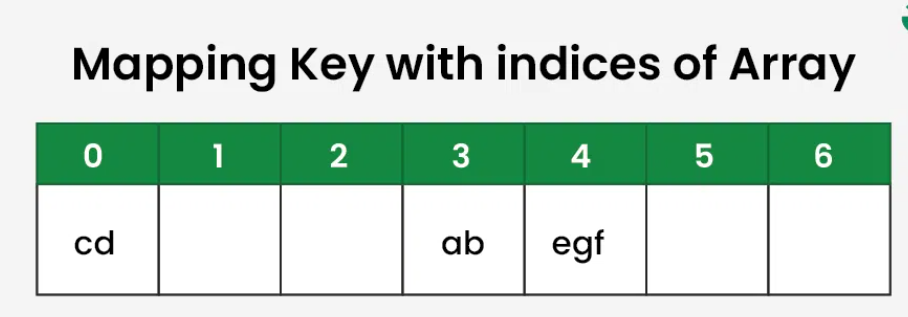

Teknik di atas memungkinkan kita untuk menghitung lokasi string tertentu dengan menggunakan fungsi hash sederhana dan dengan cepat menemukan nilai yang tersimpan di lokasi tersebut. Oleh karena itu, ide hashing tampaknya merupakan cara yang bagus untuk menyimpan pasangan (kunci, nilai) data dalam sebuah tabel.

### **Fungsi Hash**

Fungsi hash adalah fungsi yang menerima input (atau kunci) dengan ukuran sembarang dan mengubahnya menjadi nilai berukuran tetap, yang disebut nilai hash atau kode hash.

Misalnya, menggunakan metode modulo: H(x) = x % 10

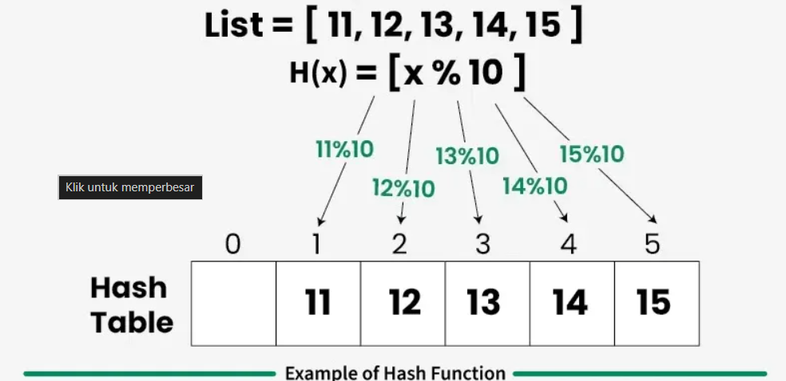

Fungsi ini mengubah angka besar apa pun menjadi nilai antara 0 dan 9, sehingga cocok untuk pengindeksan dalam tabel hash. Hashing memungkinkan penyimpanan yang efisien dan pengambilan data yang cepat.

### **Contoh Fungsi Hash**

Berikut adalah contoh yang menunjukkan bagaimana kunci input dipetakan ke nilai hash untuk penyimpanan dan pengambilan yang efisien.

**1. Nomor Telepon sebagai Tombol Input**

Gunakan dua digit terakhir dari nomor telepon sebagai nilai hash.

```
- Fungsi Hash
     h(k) = k mod 100
```

- Ukuran tabel hash adalah 100, sehingga indeks yang valid berkisar dari 0 hingga 99.
- Dengan mengambil dua digit terakhir, output selalu berada dalam rentang ini.

**Catatan :** Mengambil dua digit pertama bukanlah pilihan yang baik karena banyak nomor telepon memiliki digit awal yang sama, yang menyebabkan distribusi yang buruk dan lebih banyak tabrakan.

**2. String Bahasa Inggris Huruf Kecil sebagai Tombol**

Berikan nilai pada karakter (a = 1, b = 2, ..., z = 26), jumlahkan, dan ambil modulonya.

```
- Fungsi Hash:
     h(s) = (jumlah nilai karakter) mod 100
```

**Pendekatan yang Lebih Baik (Jumlah Tertimbang):**

Gunakan bobot posisi untuk karakter guna mengurangi tabrakan.

```
- Fungsi Hash yang Lebih Baik (konseptual):
     h(s) = (Σ nilai(s[i]) × bobot[i]) mod 100
     Hal ini bersifat konseptual karena bobotnya tidak tetap dan dapat bervariasi.
```

Setiap karakter memberikan kontribusi yang berbeda berdasarkan posisinya, sehingga meningkatkan distribusi dan mengurangi benturan.

**Sifat-Sifat Fungsi Hash**

Fungsi hash yang baik harus memenuhi properti tertentu untuk memastikan penyimpanan, pengambilan, dan keamanan data yang efisien dan andal.

- Deterministik : Sebuah fungsi hash harus secara konsisten menghasilkan output yang sama untuk input yang sama.
- Ukuran Output Tetap : Output dari fungsi hash harus memiliki ukuran tetap, terlepas dari ukuran inputnya.
- Efisiensi : Fungsi hash harus mampu memproses input dengan cepat.
- Keseragaman : Fungsi hash harus mendistribusikan nilai hash secara seragam di seluruh ruang keluaran untuk menghindari pengelompokan.
- Ketahanan terhadap serangan pre-image : Secara komputasi, seharusnya tidak mungkin untuk membalikkan fungsi hash, yaitu, untuk menemukan input asli berdasarkan nilai hash yang diberikan.
- Ketahanan terhadap benturan (Collision Resistance ): Seharusnya sulit untuk menemukan dua input berbeda yang menghasilkan nilai hash yang sama.
- Efek Longsoran : Perubahan kecil pada input akan menghasilkan nilai hash yang berbeda secara signifikan.

**Aplikasi Fungsi Hash** Fungsi hash banyak digunakan di berbagai bidang karena efisiensi dan fleksibilitasnya:

- Tabel Hash : Penggunaan fungsi hash yang paling umum dalam DSA adalah pada tabel hash, yang menyediakan cara efisien untuk menyimpan dan mengambil data.
- Integritas Data : Fungsi hash digunakan untuk memastikan integritas data dengan menghasilkan checksum.
- Kriptografi : Dalam aplikasi kriptografi, fungsi hash digunakan untuk membuat algoritma hash yang aman seperti SHA-256.
- Struktur Data : Fungsi hash digunakan dalam berbagai struktur data seperti filter Bloom dan himpunan hash.

**Jenis-jenis Fungsi Hash**

Berbagai teknik hashing digunakan tergantung pada kebutuhan aplikasi. Berikut adalah jenis-jenis yang umum digunakan:

**1. Metode Pembagian**

Metode pembagian menghitung nilai hash sebagai sisa ketika kunci dibagi dengan m, di mana m biasanya dipilih sebagai bilangan prima.

```
- h ( k )= k mod m
     Di mana k adalah kunci dan m biasanya dipilih sebagai bilangan prima.
```

**Keuntungan :**

- Mudah diimplementasikan.
- Berfungsi dengan baik jika m adalah bilangan prima.

**Kekurangan :**

- Distribusi yang buruk jika m tidak dipilih dengan bijak.

**2. Metode Perkalian** Dalam metode ini, kunci dikalikan dengan konstanta A (di mana 0 < A < 1). Bagian pecahan dari hasilnya kemudian dikalikan dengan m untuk mendapatkan nilai hash.

```
- h ( k )=⌊ m * (( k * A) mod 1)⌋
    Di mana ⌊ ⌋ menunjukkan fungsi lantai.
```

Berbeda dengan metode pembagian, teknik ini kurang bergantung pada nilai m, sehingga lebih fleksibel dalam praktiknya.

**Keuntungan :**

Memberikan distribusi yang lebih baik dalam banyak kasus. Kurang sensitif terhadap ukuran meja.

**Kekurangan :**

- Perhitungannya sedikit lebih kompleks.

**3. Metode Titik Tengah Persegi**

Metode ini melibatkan pengkuadratan kunci dan mengekstrak bagian tengah dari hasilnya untuk menghasilkan nilai hash.

```
- Langkah-langkah :

1. Persegikan kuncinya.
2. Ambil angka tengah dari nilai kuadrat tersebut.
```

Mengkuadratkan kunci membantu menyebarkan angka-angka, yang seringkali menghasilkan distribusi nilai hash yang lebih seragam.

**Keuntungan :**

- Menghasilkan distribusi nilai hash yang baik.

**Kekurangan :**

- Mungkin memerlukan upaya komputasi yang lebih besar.

**4. Metode Melipat** Dalam metode pelipatan (folding), kunci dibagi menjadi beberapa bagian yang lebih kecil, dan bagian-bagian ini digabungkan (biasanya dengan penjumlahan) untuk menghasilkan nilai hash.

**Langkah-langkah :**

```
1. Bagilah kunci tersebut menjadi beberapa segmen yang sama besar atau hampir sama besar.
2. Jumlahkan semua segmen untuk mendapatkan jumlah sementara.
3. Terapkan operasi modulo (jika diperlukan) untuk menyesuaikan ukuran tabel hash.
4. Secara opsional, balikkan segmen-segmen yang berselang-seling sebelum menambahkannya untuk meningkatkan distribusi.
```

**Keuntungan :**

- Sederhana dan mudah diterapkan.
- Cocok untuk tombol berukuran besar.
- Fleksibel dalam strategi partisi.
- **Kekurangan :**
- Kualitas bergantung pada bagaimana kunci tersebut dibagi.
- Nilai mungkin tidak terdistribusi secara seragam jika komponennya serupa.

**5. Fungsi Hash Kriptografi**

Fungsi hash ini dirancang untuk keamanan, bukan kecepatan. Fungsi ini digunakan dalam aplikasi di mana perlindungan data sangat penting.

```
- Contohnya termasuk SHA-256 dan SHA-3, yang banyak digunakan dalam aplikasi keamanan seperti hashing kata sandi dan blockchain.
```

Mereka memastikan sifat-sifat yang kuat seperti ketahanan terhadap serangan pre-image, ketahanan terhadap serangan second pre-image, dan ketahanan terhadap serangan collision, sehingga cocok untuk sistem yang aman.

**Keuntungan :**

- Sangat aman dan andal.

**Kekurangan :**

- Lebih lambat dibandingkan dengan fungsi hash non-kriptografis.

**6. Hashing Universal** Hashing universal menggunakan sekumpulan fungsi hash dan memilih salah satunya secara acak saat runtime. Tujuannya adalah untuk meminimalkan probabilitas tabrakan terlepas dari distribusi input.

```
- h ( k )=(( a * k + b ) mod p ) mod m
    Di mana a dan b adalah konstanta yang dipilih secara acak, p adalah bilangan prima yang lebih besar dari m , dan k adalah kuncinya.
```

Dengan memperkenalkan unsur acak, metode ini mencegah penyerang atau input terburuk menurunkan kinerja.

**Keuntungan :**

- Mengurangi kemungkinan tabrakan.
- Lebih tangguh terhadap input yang bersifat antagonis.

**Kekurangan :**

- Membutuhkan lebih banyak daya komputasi dan penyimpanan.

**7. Hashing Sempurna** Perfect hashing adalah teknik yang digunakan untuk membangun fungsi hash untuk sekumpulan kunci tetap, memastikan bahwa setiap kunci dipetakan ke indeks unik tanpa adanya benturan (collision).

Perfect hashing umumnya diklasifikasikan menjadi dua jenis utama:

- Minimal Perfect Hashing: Memastikan bahwa rentang fungsi hash sama dengan jumlah kunci.
- Hashing Sempurna Non-minimal: Rentangnya mungkin lebih besar daripada jumlah kunci.

**Keuntungan :**

- Menghilangkan tabrakan sepenuhnya.

**Kekurangan :*** -- Sulit untuk dibangun.

- Tidak cocok untuk data dinamis.